# Informe

##### Outliers

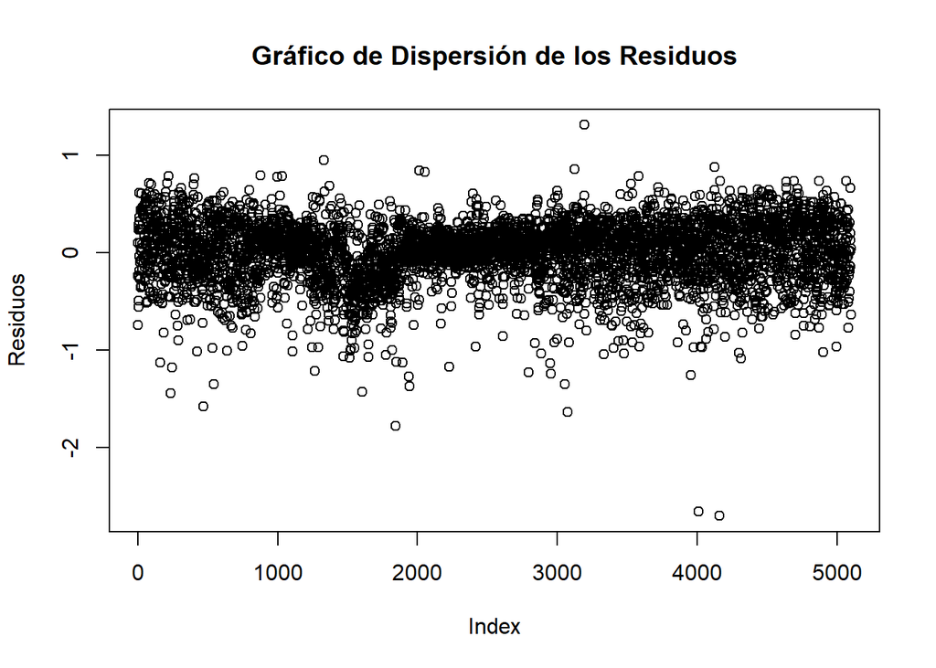

```r
# Gráfico de dispersión de los residuos
plot(modelo3$residuals, main = "Gráfico de Dispersión de los Residuos", ylab = "Residuos")
```

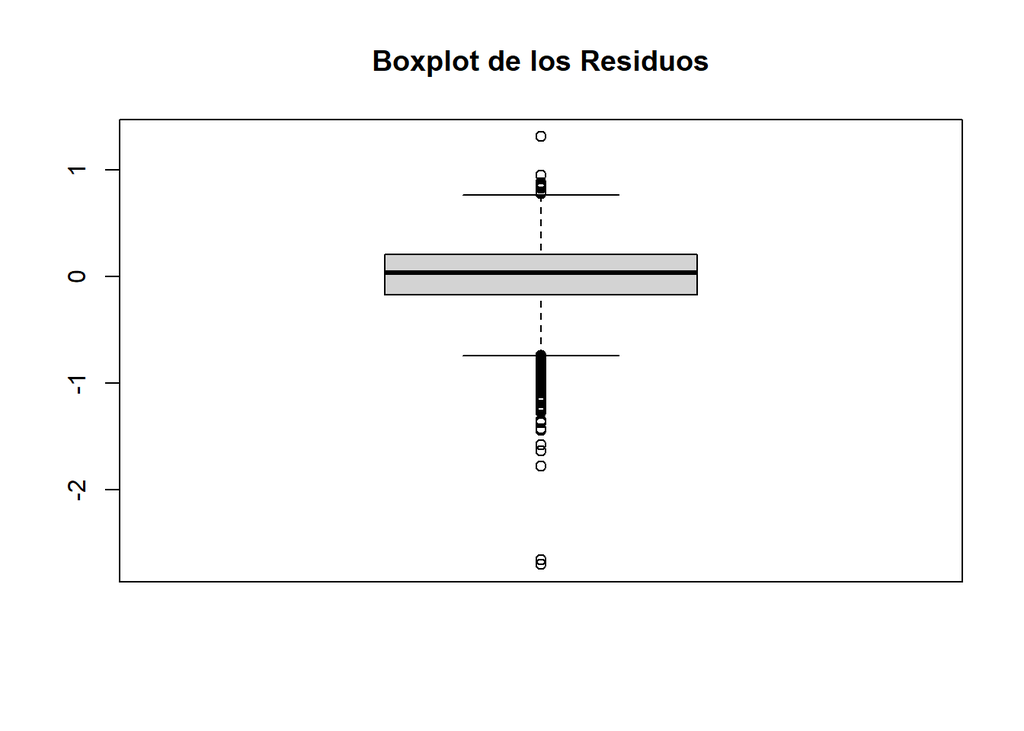

```r
# Boxplot de los residuos
boxplot(modelo3$residuals, main = "Boxplot de los Residuos")
```

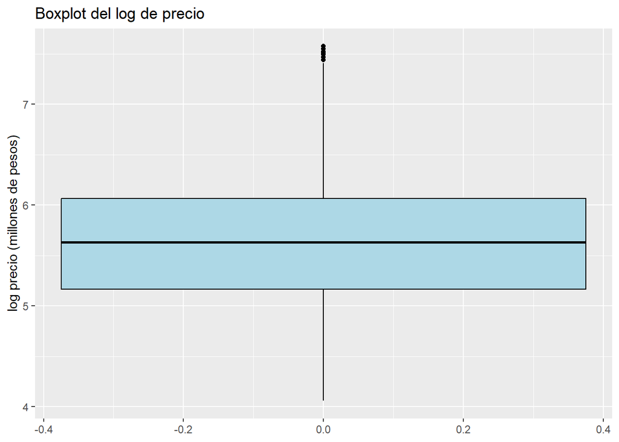

```r
ggplot(data1, aes(y = log(preciom))) +
  geom_boxplot(fill = "lightblue", color = "black") +
  labs(y = "log precio (millones de pesos)",
       title = "Boxplot del log de precio")
```

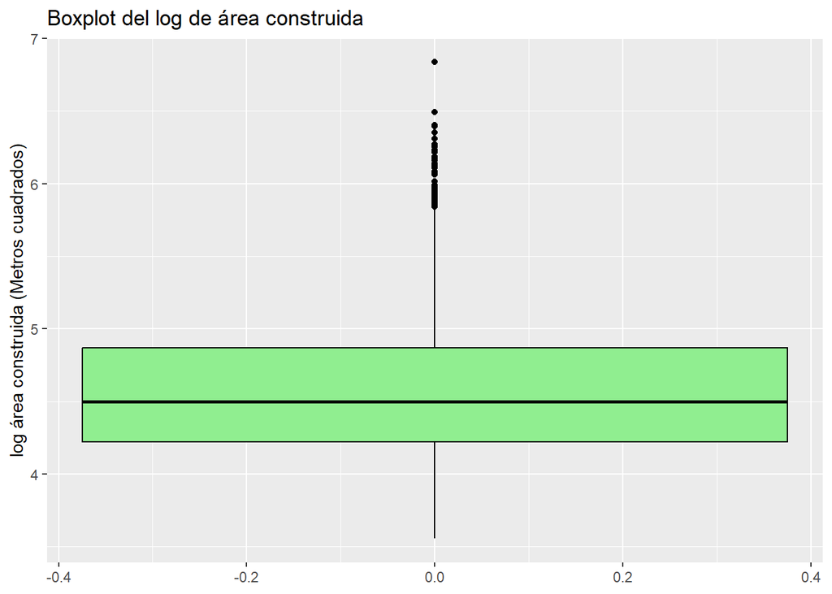

```r
ggplot(data1, aes(y = log(areaconst))) +
  geom_boxplot(fill = "lightgreen", color = "black") +
  labs(y = "log área construida (Metros cuadrados)",
       title = "Boxplot del log de área construida")
```

Con estos gráficos y los hechos para cada variable, vemos que hay bastante valores atípicos en ambas variables y en los residuos que pueden generar sesgos en los estimadores de los coeficientes.

### Comparación

```r
stargazer(lm_model,modelo1, modelo2, modelo3, type="text", df=FALSE)
```

```
##
## ==========================================================================
##                                      Dependent variable:
##                     ------------------------------------------------------
##                               preciom                  log(preciom)
##                          (1)           (2)          (3)           (4)
## --------------------------------------------------------------------------
## areaconst             3.456***                    0.007***
##                        (0.033)                    (0.0001)
##
## log(areaconst)                     505.335***                  1.196***
##                                      (4.601)                    (0.009)
##
## Constant             -22.797***   -1,954.709***   4.840***     0.178***
##                        (4.328)      (21.253)      (0.011)       (0.042)
##
## --------------------------------------------------------------------------
## Observations            5,099         5,099        5,099         5,099
## R2                      0.687         0.703        0.617         0.772
## Adjusted R2             0.687         0.703        0.617         0.772
## Residual Std. Error    161.887       157.642       0.405         0.312
## F Statistic         11,175.520*** 12,063.700*** 8,208.982*** 17,225.730***
## ==========================================================================
## Note:                                          *p<0.1; **p<0.05; ***p<0.01
```

En ningún modelo se cumplieron los supuestos, esto dado a que es difícil predecir solo con una variable y un modelo tan sencillo, sin embargo el modelo en el que tanto el área como el precio se expresaban como logaritmos tuvo el mejor ajuste de todos, esto se puede ver en las gráficas y también con el R2 que es el mas alto de todos y nos indica que el modelo explica en un 77.2% la variabilidad del logaritmo del precio dado el logaritmo del área construida.

# Resultados

Luego de hacer el modelo y sus ajustes vemos que realmente ninguno cumplió con algún supuesto, además tenemos datos muy variables y con bastantes datos atípicos a pesar de haber hecho el filtro de solo usar apartamentos. De igual forma hubieron modelos mejores que otros y con buenos resultados para un modelo tan simple y con tan pocas variables.

# Conclusiones

A pesar de que se ve cierto patrón entre el área y el precio a simple vista, no es uno que se pueda explicar correctamente de forma lineal. De entre todas las aproximaciones que se hicieron la mejor fue usando el logaritmo de ambas variables como se ve en el gráfico en el que comparamos los distintos modelos, además este modelo también tiene el R2 mas alto que nos indica que el logaritmo del área indica en un 77.2% la variabilidad del logaritmo del precio. A pesar de que fue el mejor modelo, no cumplió con ninguno de los supuestos que legitiman a un modelo confiable por lo que no es realmente útil mas es bueno para lo simple que es.

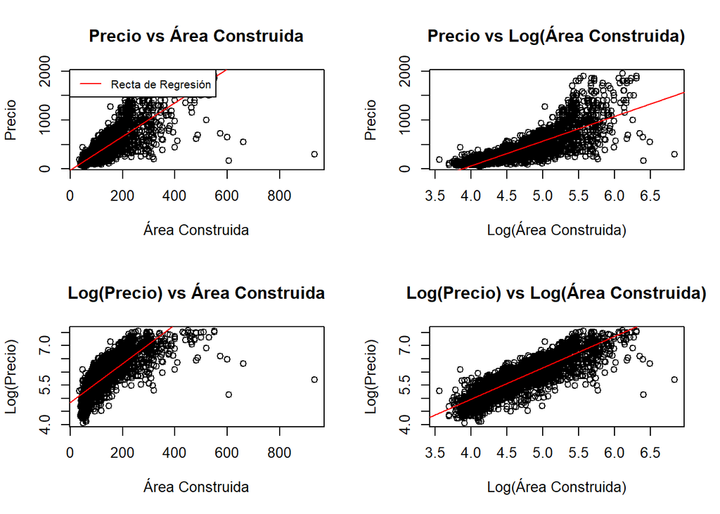

```r
# Dividir el área de trazado en una cuadrícula de 2x2
par(mfrow = c(2, 2))

# Gráfico 1: Precio vs Área Construida
plot(areaconst, preciom, main = "Precio vs Área Construida", xlab = "Área Construida", ylab = "Precio")
abline(lm_model, col = "red")
legend("topleft", legend = "Recta de Regresión", col = "red", lty = 1, cex = 0.8)

# Gráfico 2: Precio vs Log(Área Construida)
plot(log(areaconst), preciom, main = "Precio vs Log(Área Construida)", xlab = "Log(Área Construida)", ylab = "Precio")
abline(modelo1, col = "red")

# Gráfico 3: Log(Precio) vs Área Construida
plot(areaconst, log(preciom), main = "Log(Precio) vs Área Construida", xlab = "Área Construida", ylab = "Log(Precio)")
abline(modelo2, col = "red")

# Gráfico 4: Log(Precio) vs Log(Área Construida)
plot(log(areaconst), log(preciom), main = "Log(Precio) vs Log(Área Construida)", xlab = "Log(Área Construida)", ylab = "Log(Precio)")
abline(modelo3, col = "red")
```

Con todo esto en cuenta se ofrecen cuatro soluciones:

1. Crear modelos lineales con ajustes para cada tipo de vivienda y para cada zona. Es posible que la alta variabilidad de los datos y valores atípicos vengan del origen distinto de los datos por lo que, si se crearan distintos filtros como por zona, tipo e incluso estrato (si se ve necesario) se podría construir un modelo lineal simple que represente mejor la relación entre estas 2 variables para cada subconjunto.
2. Crear modelos lineales más complejos. Se podrían usar modelos usando más variables, es decir modelos de regresión múltiple, esto tendría en cuenta la variabilidad de las zonas, tipos y estratos dentro del mismo modelo lo que podría generar resultados más confiables y un modelo más preciso.
3. Usar otros tipos de modelos más complejos. Utilizando modelos más complejos como por ejemplo los de aprendizaje automático podríamos tener una regresión más precisa con los filtros e hiperparametros correspondientes.
4. Hacer una limpieza exhaustiva previa de los datos antes de realizar el modelo. Si se podan los datos atípicos y se estandarizan mas los datos se podría crear un modelo que encaje mejor, sin embargo esto reduciría un poco el alcance del modelo y se limitaría a los datos cercanos al promedio.

En conclusión, este tipo de modelos puede resultar útil mas no infalible, puede servir de guía para establecer precios y estrategias más todavía carece de la minuciosidad necesaria para ser confiable por sí solo.